# Genomics Project Report

Master’s Degree Project Report

roa hanoun

2026-03-28

# Abstract

# Introduction

## Background: Cardiomyopathy

Cardiomyopathy is a group of diseases that affect the heart muscle, leading to structural and functional abnormalities that impair the heart’s ability to pump blood efficiently. These conditions can result in serious clinical outcomes, including heart failure, arrhythmias, and sudden cardiac death.

Many forms of cardiomyopathy have a genetic basis. Inherited mutations have been associated with several types of the disease, such as hypertrophic, dilated, restrictive, and arrhythmogenic cardiomyopathy, as well as left ventricular non-compaction and ion channelopathies. These mutations often affect genes involved in heart muscle structure and function, including those related to the sarcomere, cytoskeleton, and ion channels.

## Aim and Research Questions

The aim of this project is to identify and evaluate genetic variants associated with cardiomyopathy using DNA sequencing data. By comparing the patient’s DNA sequence to established cardiomyopathy-associated gene panels, potentially pathogenic variants can be detected and assessed. Using next-generation sequencing (NGS) technologies, this project seeks to identify genetic variants that may contribute to the development and progression of cardiomyopathy and to evaluate their relevance in a diagnostic context.

# Materials and Methods

## Dataset Description

### Data Source

The dataset used in this project consists of DNA sequencing data obtained from patients diagnosed with cardiomyopathy. The data were provided as part of a master-level genomics course and were used for educational and research purposes.

### Number of Samples

> The dataset consists of multiple patient samples derived from cardiomyopathy cases. In this project, the analysis focuses on **Sample 1**, which is provided as paired-end sequencing data consisting of two read files (forward and reverse reads).

### File Format

> The sequencing data were provided in FASTQ format, containing the raw reads generated by next-generation sequencing and used as the input for the analysis. This is the first line in the file:

> ```
> @M01234:01:000000000-A1B2C:1:1101:16810:1655 2:N:0:2
> AATGACATTGATCTCCACAGCCATCAAGAGCCCATTCAAGATGACCATCATGCCTGTGATGCAGAAACGCAGGTTTGATATGTCCAAGCCAGACTGACAGTACTTAACCAATTTTATTGTTTTTGTAATAAAGGCCCTTACCCAATACAGG
> +
> 11A11DDFDDB@GGGGCF11FA1GGF1GBCCBFHHHHGHFCGHFFHFHB1F1FFHBF1BG2DFBGF1FC/EE/A1D/1A2DBGGHFFFE/000FG11BF1GFGFHHFHHEHHHGHHGBDFHFHG/BE2F2>FH1>E/FE11BG</B1<110
> ```

## Analysis Environment

- **Workflow platform:** Galaxy
- **Programming language:** R
- **Reporting framework:** R Markdown

Version control and collaboration were managed using **GitHub**, allowing transparent tracking of changes and shared development of the analysis. **Microsoft Teams** was used as the primary communication platform to coordinate the workflow, discuss results, and share progress with each other and with the course instructor.

# Analysis Workflow

The overall analysis workflow is designed to identify and characterize genetic variants from DNA sequencing data in a systematic and reproducible manner. The workflow includes quality control of raw reads, read preprocessing, alignment to a reference genome, variant calling, and variant filtering and annotation. Each step of the analysis is briefly introduced here and discussed in detail in the following subsections.

## Quality Control of Raw Reads

Quality control of raw sequencing reads was performed to evaluate data quality before downstream analysis. For this purpose, the tool **Falco** was used. A `.fastQ.gz` file was provided as input, and Falco generates several plots as output. Each plot highlights a specific aspect of the sequencing data, such as base quality scores, GC content, sequence length distribution, and the presence of adapter contamination, and provides a quality assessment in the form of **pass, warn, or fail**.

The quality control results were examined to determine whether read trimming or filtering was required before alignment. Key observations from the quality reports are summarized and interpreted in this section.

### Basic Statistics

| Measure | Value |
| --- | --- |
| Filename | Sample1_0394321_L001_R1_001_fastq_gz |
| File type | Conventional base calls |
| Encoding | Sanger / Illumina 1.9 |
| Total Sequences | 1424257 |
| Sequences Flagged As Poor Quality | 0 |
| Sequence length | 32 - 151 |
| %GC: | 43 |

## **Per base sequence quality: pass**

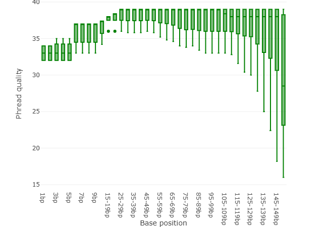

## **Per tile sequence quality : pass**

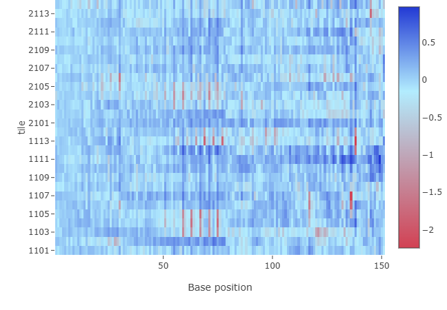

## **Per sequence quality scores : pass**

Per sequence quality scores examine whether subsets of sequences have universally low quality values, which may indicate systematic issues like poor imaging at flow cell edges. A warning is issued if the most frequently observed mean quality falls below **27 (0.2% error rate)**, and failure occurs below **20 (1% error rate)**. In our results, the majority of sequences have mean quality scores above 30, well above both thresholds, confirming that the data passes this quality check.

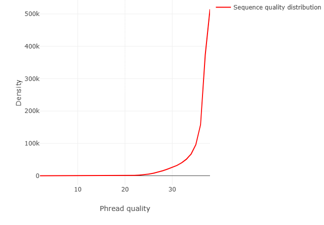

## **Per base sequence content : fail**

Per base sequence content analyzes the proportion of each nucleotide (A, T, C, G) at every position across all reads. In a properly balanced library, the lines for each base should run parallel with only small differences between A and T or G and C. A warning is issued if the difference between A and T or G and C exceeds **10%** at any position, and failure occurs if the difference exceeds **20%**.

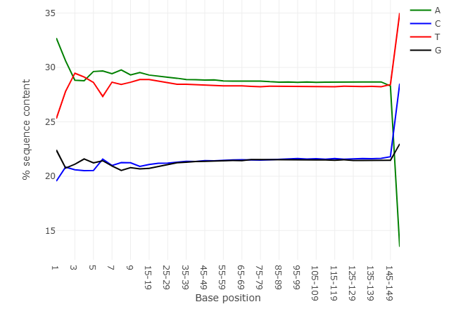

## **Per sequence GC content: pass**

Per sequence GC content measures the distribution of G and C bases across all reads, plotted as the number of reads versus GC percentage. A normal distribution is expected for high-quality data, with the peak matching the genome’s overall GC content.

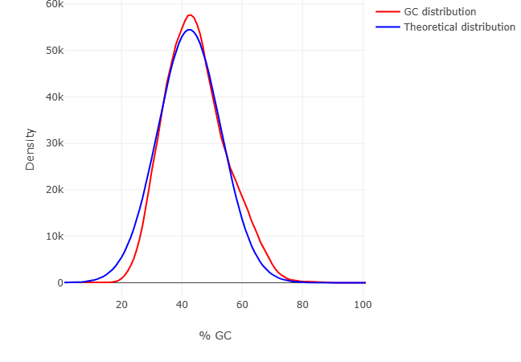

## **Per base N content : pass**

Per base N content measures the proportion of ambiguous base calls (N) at each position across all reads. Low N content, especially near read ends, is normal and expected. A warning is issued if any position exceeds **5%** N content, and failure occurs if above **20%**. Our results passed this module, with N content remaining consistently low **(below 0.04%)** across all positions. This indicates high-quality base calling with minimal ambiguity throughout the sequencing run.

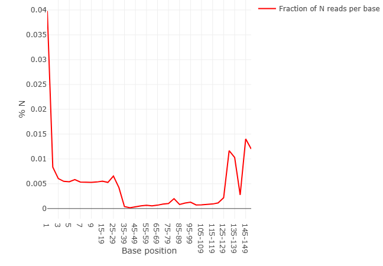

## **Sequence Length Distribution : warn**

Sequence length distribution analyzes the range of fragment sizes in the raw sequencing data. A warning is issued if all sequences are not the same length, while failure occurs if any sequence has zero length. Our results show a warning in this module, indicating that the reads in our raw dataset are not all identical in length.

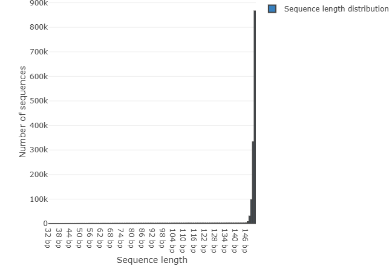

## **Sequence Duplication Levels : warn**

Sequence duplication levels measure the proportion of duplicate reads in the sequencing data. This module identifies reads that appear more than once, which can indicate over-amplification during library preparation. A warning is issued when non-unique reads make up more than **20%** of the total sequences. Our results show a warning in this module, indicating a moderate level of duplication in the dataset.

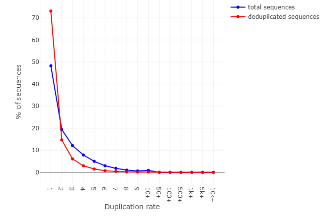

## **Overrepresented sequences : pass**

Overrepresented sequences are those that appear more frequently than expected in the dataset. Our results passed this module as no overrepresented sequences were found.

## **Adapter Content : pass**

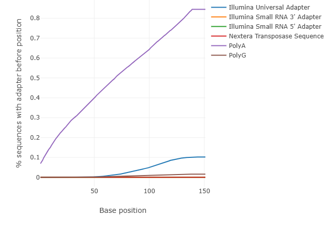

Based on the initial quality assessment, reads were trimmed to remove low-quality bases and sequencing adapters, ensuring that only high-quality sequences were retained for downstream analysis.

**Tool used:** (`Trimmomatic`)

### Trimming Parameters

Based on our quality control results, we selected specific parameters for trimming with Trimmomatic. We kept the default values for the adapter clipping settings, and added several parameters to address issues identified in the quality report: we applied CROP to 145 bases to remove positions beyond 145 that showed noise in the per base sequence content, used HEADCROP of 7 bases to eliminate low-quality bases from the read starts, and set MINLEN to 50 to discard short reads after trimming, ensuring high-quality data for subsequent analysis.

**Tool Parameters**

| Input Parameter | Value |
| --- | --- |
| Single-end or paired-end reads? | pair_of_files |
| Input FASTQ file (R1/first of pair) |  |
| Input FASTQ file (R2/second of pair) |  |
| Perform initial ILLUMINACLIP step? | true |
| Select standard adapter sequences or provide custom? | standard |
| Adapter sequences to use | TruSeq3 (paired-ended, for MiSeq and HiSeq) |
| Maximum mismatch count which will still allow a full match to be performed | 2 |
| How accurate the match between the two ‘adapter ligated’ reads must be for PE palindrome read alignment | 30 |
| How accurate the match between any adapter etc. sequence must be against a read | 10 |
| Minimum length of adapter that needs to be detected (PE specific/palindrome mode) | 8 |
| Always keep both reads (PE specific/palindrome mode)? | true |
| Select Trimmomatic operation to perform | SLIDINGWINDOW |
| Number of bases to average across | 4 |
| Average quality required | 20 |
| Select Trimmomatic operation to perform | CROP |
| Number of bases to keep from the start of the read | 145 |
| Select Trimmomatic operation to perform | HEADCROP |
| Number of bases to remove from the start of the read | 7 |
| Select Trimmomatic operation to perform | MINLEN |
| Minimum length of reads to be kept | 50 |
| Quality score encoding | Nothing selected. |
| Output trimlog file? | false |
| Output trimmomatic log messages? | false |

### Quality Control Results After Trimming

#### - Sample1_R1_fastq_gz_R1 paired

## **Basic Statistics: pass**

| Measure | Value |
| --- | --- |
| Filename | Trimmomatic on Sample1_0394321_L001_R1_001_fastq_gz _R1 paired_ |
| File type | Conventional base calls |
| Encoding | Sanger / Illumina 1.9 |
| Total Sequences | 1206159 |
| Sequences Flagged As Poor Quality | 0 |
| Sequence length | 50 - 138 |
| %GC: | 42 |

## **Per base sequence quality: pass**

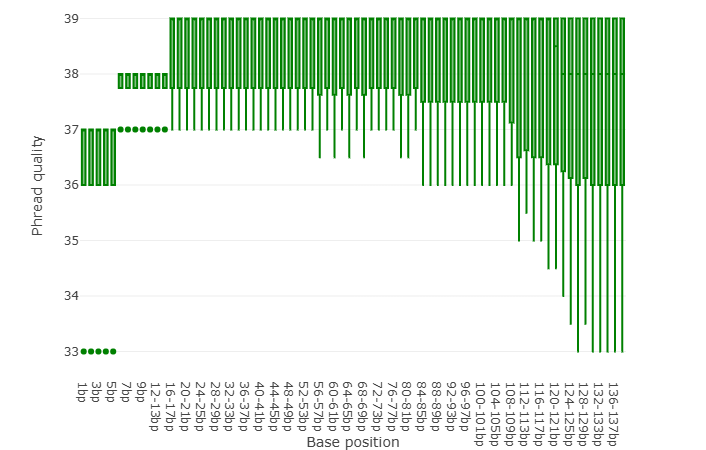

## **Per tile sequence quality: pass**

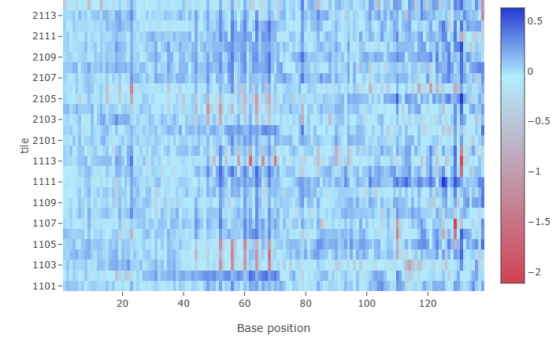

## **Per sequence quality scores: pass**

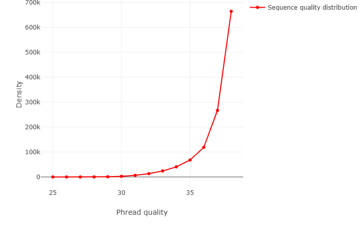

## **Per base sequence content : pass**

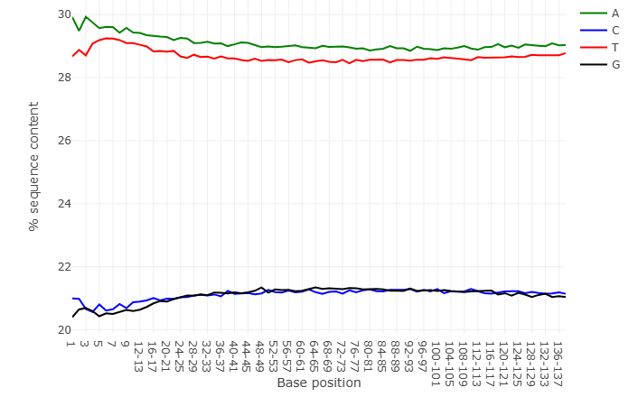

## **Per sequence GC content: pass**

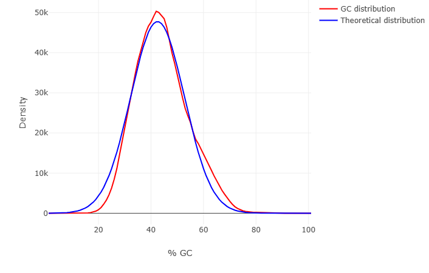

## **Per base N content : pass**

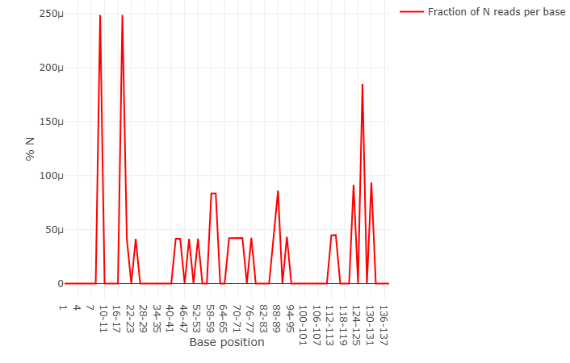

## **Sequence Length Distribution : warn**

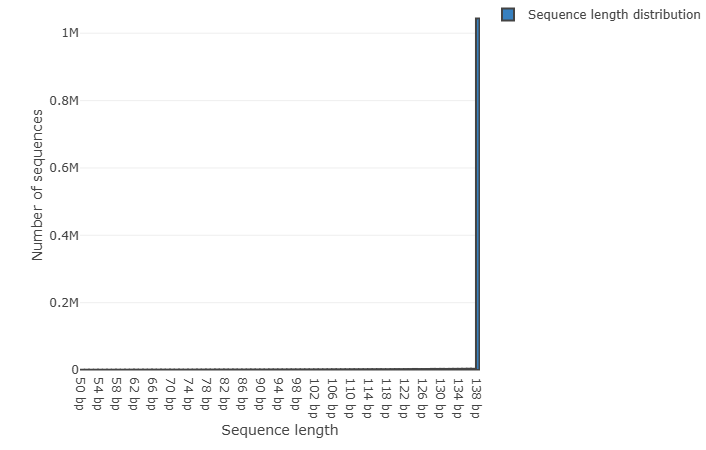

## **Sequence Duplication Levels : warn**

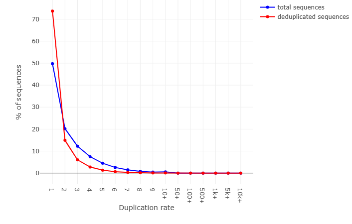

## **Overrepresented sequences : pass**

### No overrepresented sequences

## **Adapter Content : pass**

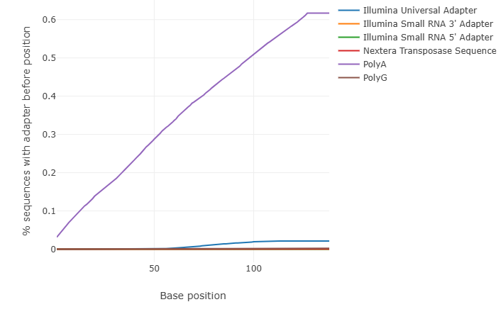

#### - Sample1_R2_fastq_gz_R2 paired

## **Basic Statistics: pass**

| Measure | Value |
| --- | --- |
| Filename | Trimmomatic on Sample1_0394321_L001_R2_001_fastq_gz _R2 paired_ |
| File type | Conventional base calls |
| Encoding | Sanger / Illumina 1.9 |
| Total Sequences | 1206159 |
| Sequences Flagged As Poor Quality | 0 |
| Sequence length | 50 - 138 |
| %GC: | 42 |

## **Per base sequence quality: pass**

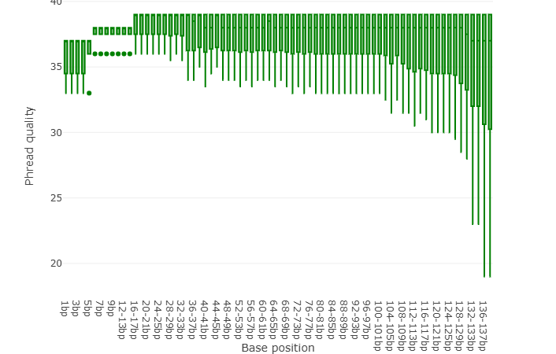

## **Per tile sequence quality: pass**

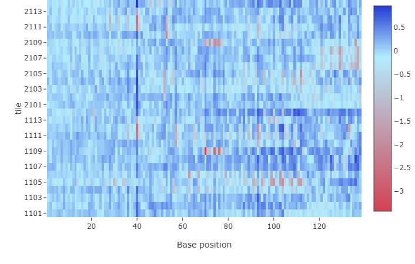

## **Per sequence quality scores: pass**

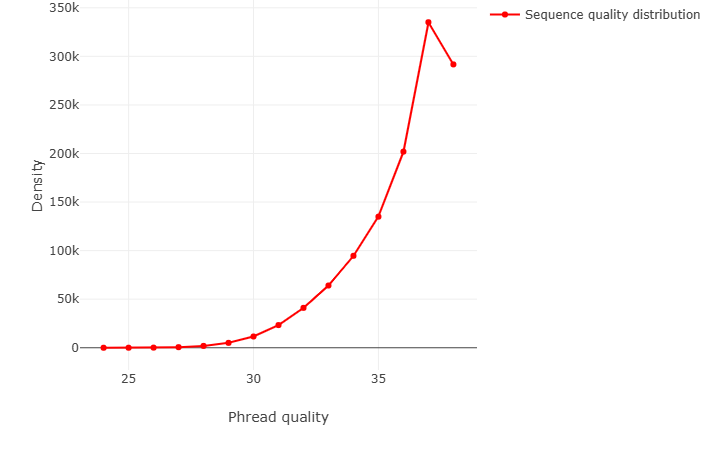

## **Per base sequence content : warn**

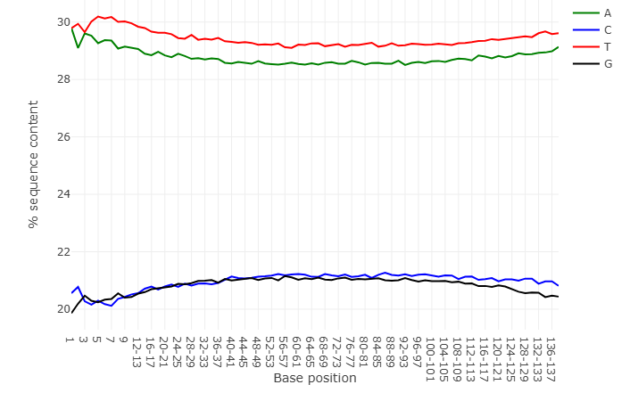

## **Per sequence GC content: pass**

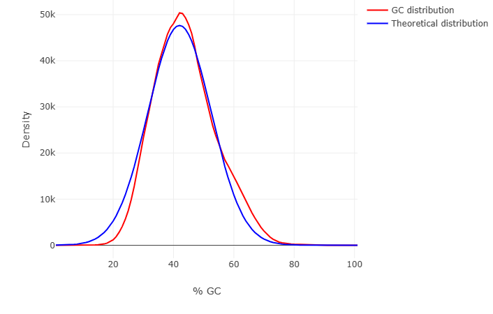

## **Per base N content : pass**

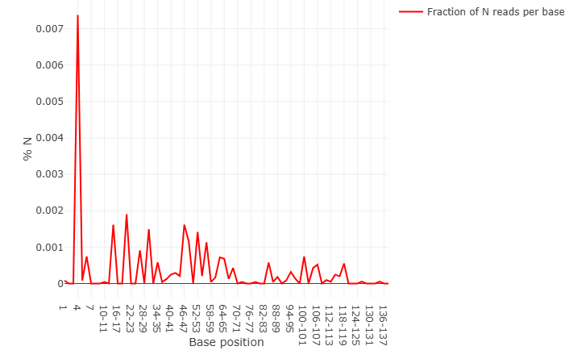

## **Sequence Length Distribution : warn**

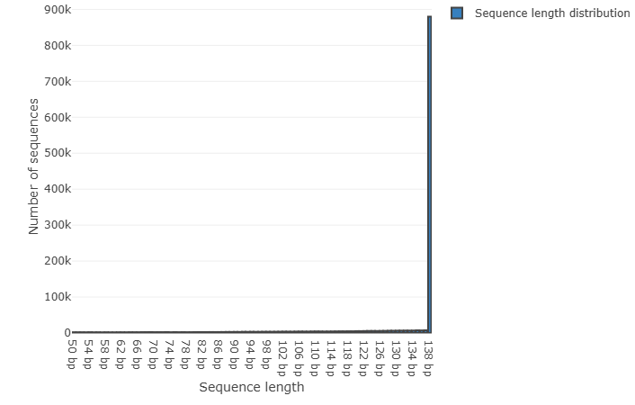

## **Sequence Duplication Levels : warn**

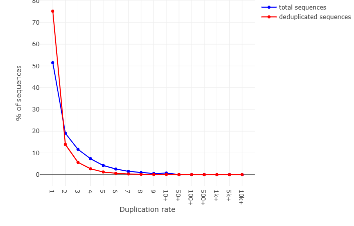

## **Overrepresented sequences : pass**

### No overrepresented sequences

## **Adapter Content : pass**

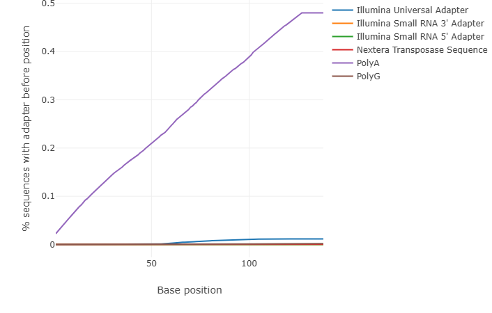

Filtered reads were aligned to the appropriate human reference genome using a short-read aligner.

**Alignment tool: BWA**

### Marking Duplicate Mapped Reads

Before analyzing differences between the reference genome and our patient sample, duplicate mapped reads must be identified. Duplicates arise from PCR amplification bias (multiple copies of the same fragment) or optical artifacts during sequencing, and if unaddressed, can lead to false positive variant calls and inaccurate coverage estimates.

We used `MarkDuplicates` tool on the coordinate-sorted BAM files from the previous mapping step. The algorithm identifies duplicate pairs by comparing read coordinates, orientations, and insert sizes, then adds a duplicate flag to each identified duplicate read. Importantly, reads are flagged but not removed, preserving data integrity while allowing downstream tools to ignore these flagged reads during analysis.

**The output includes:**

A marked BAM file `.marked.bam`: alignment data with duplicate flags

A BAM index file `.bai`: enables rapid random access for visualization

These files serve as input for the next step: visualizing the mapping data without the confounding effects of duplicates.

### Visualizing the Mapping Data

#### Integrative Genomics Viewer (IGV)

To visually inspect the mapped reads and identify potential variants, we used the **Integrative Genomics Viewer (IGV)**. This tool enabled visualization of read alignment, coverage depth, and nucleotide changes across target regions, using the BED file to navigate directly to genes of interest.

#### Reference Genome and Data Files

The reference genome used for visualization was **GRCh38/hg38** (Genome Reference Consortium Human Build 38), which provides a high-quality assembly of the human genome.

For this visualization step, we used two primary input files:

1. **Marked BAM file** (`dataset.bam`): Contains the aligned reads with duplicate flags, enabling accurate visualization without PCR bias.
2. **Target BED file** (`CAR_0394321_en-20_target_v2_8.bed`): A interval file specifying all captured regions in the gene panel.

The BED file contains four columns specifying the chromosome, exon start and end positions, and gene name (e.g., PSEN2, LMNA), allowing us to navigate directly to regions of interest. This BED file served as a navigation guide, allowing us to rapidly zoom into specific genes of interest and examine their coverage and potential variants.

#### Variant Identification

Using the BED file to navigate, we examined two different genes of interest. Below are representative examples of variants identified in this analysis:

**Figure 1: PSEN2 Gene Region**

[figure not shown]

**Figure 2: LMNA Gene Region**

[figure not shown]

Visualization of the LMNA gene showing a heterozygous variant. The aligned reads display both reference and alternative alleles (mixed colors at the variant position), with approximately equal representation. Heterozygous variants in LMNA are known to be associated with dilated cardiomyopathy (DCM).

## Mapping Quality Control

In this section, we assessed the mapping coverage for all panel genes to evaluate mapping performance. As observed in IGV, coverage levels varied significantly across regions, ranging from very high (300+) to areas with only a few reads present, which can impact variant detection reliability. Using **R** with libraries commonly used in genetic research, we calculated and reported coverage statistics for all panel genes to quantitatively assess these variations and identify undercovered regions.

### Loading the BED-data

The first step is to load the BED file containing the exon coordinates of our panel genes. The file is tab-separated and has four columns: chromosome, start, end, and gene name. We will read it into R, assign proper column names, and then examine the distribution of exons across chromosomes.

```
##   chromosome    start      end gene
## 1       chr1 77916084 77916153 NEXN
## 2       chr1 77917546 77917777 NEXN
## 3       chr1 77917940 77918058 NEXN
## 4       chr1 77918105 77918293 NEXN
## 5       chr1 77925168 77925249 NEXN
## 6       chr1 77926394 77926631 NEXN
```

```
##
##  chr1 chr10 chr11 chr12 chr14 chr15 chr17 chr18 chr19  chr2 chr20 chr22  chr3
##   175    89    42    60    85    20    15    54    17   324     5    17    54
##  chr4  chr5  chr6  chr7  chrX
##     5     8    87    29   118
```

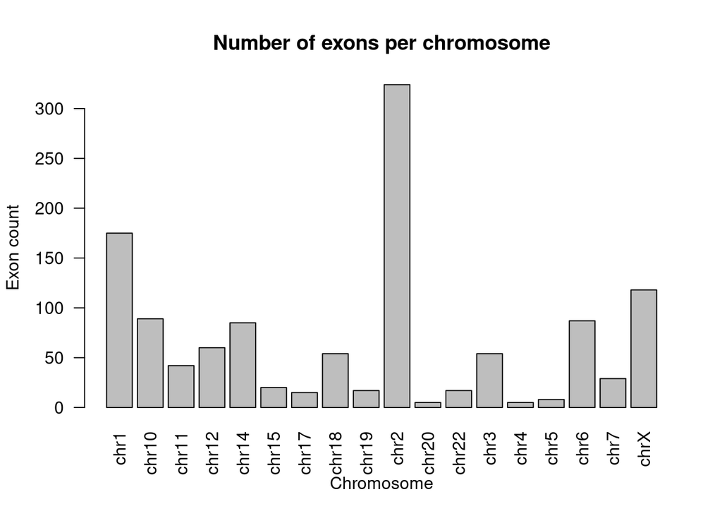

### BED-visualization

In this section, we visualized the distribution of genes across different chromosomes using the BED data. First, we reduced the data to unique chromosome-gene combinations, then counted the number of genes per chromosome and presented the results in a bar plot. This visualization provides a clear overview of how genes are distributed across chromosomes, helping to identify which chromosomes carry the most genes in our panel.

```
##   chromosome gene
## 1       chr1 NEXN
## 2       chr1 NEXN
## 3       chr1 NEXN
## 4       chr1 NEXN
## 5       chr1 NEXN
## 6       chr1 NEXN
```

```
##    chromosome  gene
## 1        chr1  NEXN
## 13       chr1  LMNA
## 25       chr1 TNNT2
## 40       chr1 PSEN2
## 50       chr1 ACTN2
## 71       chr1  RYR2
```

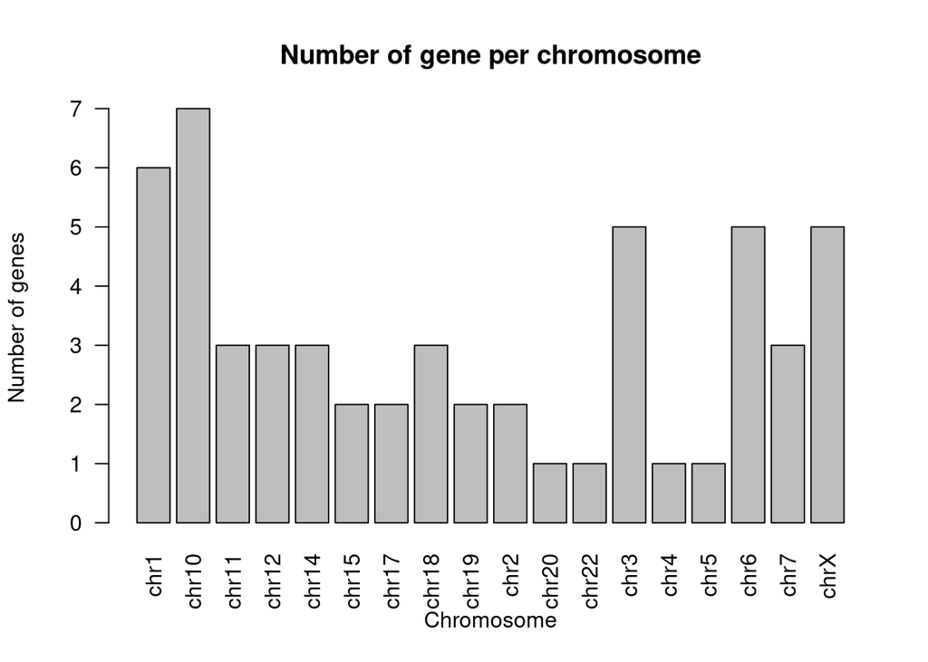

### Bioconductor

Bioconductor is a repository containing over 1800 R packages specifically designed for analyzing high-throughput biological data, which we used throughout this assignment.

**Why Convert IRanges to GRanges?**

The IRanges object contains exon positions and lengths but lacks chromosome information, making it incomplete for genomic analysis. Converting to a GRanges object adds the chromosome context, creating a complete genomic coordinate system that properly locates each exon in the genome.

### GenomicRanges objects

```
## GRangesList object of length 6:
## $ABCC9
## GRanges object with 39 ranges and 0 metadata columns:
##         seqnames            ranges strand
##            <Rle>         <IRanges>  <Rle>
##   ABCC9    chr12 21801024-21801201      *
##   ABCC9    chr12 21805154-21805331      *
##   ABCC9    chr12 21805978-21806080      *
##   ABCC9    chr12 21807326-21807499      *
##   ABCC9    chr12 21809832-21809975      *
##     ...      ...               ...    ...
##   ABCC9    chr12 21915648-21915930      *
##   ABCC9    chr12 21916917-21917123      *
##   ABCC9    chr12 21925922-21926083      *
##   ABCC9    chr12 21933762-21933943      *
##   ABCC9    chr12 21936513-21936694      *
##   -------
##   seqinfo: 18 sequences from an unspecified genome; no seqlengths
##
## ...
## <5 more elements>
```